# Week 2 homework answers

```r
library(rethinking)
```

1. Construct a linear regression of weight as predicted by height, using the adults (age 18 or greater) from the Howell1 dataset. The heights listed below were recorded in the !Kung census, but the weights were not recorded for these individuals. Provde predicted weights and 89% compatibility intervals for each of these individuals. That is, fill in the table below, using model-based predictions.

```r
data("Howell1")
d <- Howell1
d2 <- d[d$age >=18,]
```

```r
# define the average weight, x-bar
xbar <- mean(d2$height)

# fit model
m2a <- quap(
  alist(
    weight ~ dnorm( mu, sigma) ,
    mu <- a + b*(height - xbar),
    a ~ dnorm(45, 10),
    b ~ dlnorm(0, 1),
    sigma ~ dunif(0, 20)
  ),
  data=d2)
```

```r
plot(weight ~ height, data=d2, col=rangi2)
post <- extract.samples(m2a)
a_map <- mean(post$a)
b_map <- mean(post$b)
curve(a_map + b_map*(x - xbar) , add=TRUE)
```

[output not shown]

```r
mu_at_140 <- post$a + post$b * (140 - xbar)
mean(mu_at_140)
PI(mu_at_140, prob=0.89)
```

[output not shown]

```r
mu_at_160 <- post$a + post$b * (160 - xbar)
mean(mu_at_160)
PI(mu_at_160, prob=0.89)
```

[output not shown]

```r
mu_at_175 <- post$a + post$b * (175 - xbar)
mean(mu_at_175)
PI(mu_at_175, prob=0.89)
```

[output not shown]

```r
d3 <- d[d$age <13,]
```

```r
d3$A <- scale(d3$age)
d3$H <- scale(d3$height)
d3$W <- scale(d3$weight)
```

```r
sd(d3$age)
```

```
[1] 3.824657
```

```r
sd(d3$height)
```

```
[1] 21.48953
```

```r
sd(d3$weight)
```

```
[1] 5.722741
```

# single variate H

```r
mh.2H <- quap(
  alist(
    W ~ dnorm(mu, sigma) ,
    mu <- a + bH*H,
    a ~ dnorm(0, 0.2),
    bH ~ dnorm(0, 0.5),
    sigma ~ dexp(1)
  ), data=d3
)
precis(mh.2H)
```

|  | mean | sd | 5.5% | 94.5% |
| --- | --- | --- | --- | --- |
| a | 0.00 | 0.02 | -0.03 | 0.03 |
| bH | 0.96 | 0.02 | 0.93 | 1.00 |
| sigma | 0.26 | 0.02 | 0.23 | 0.28 |

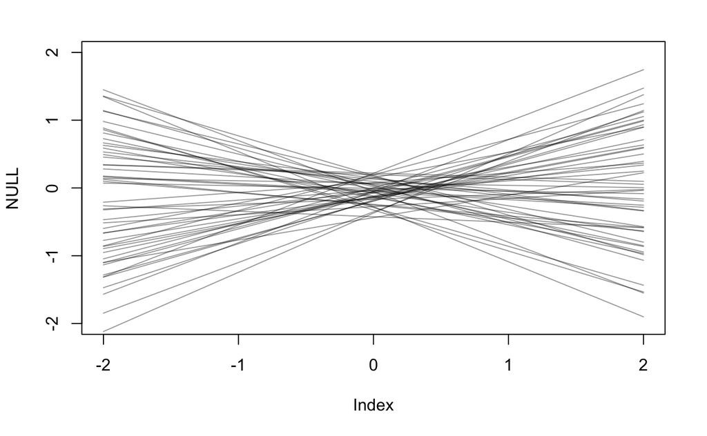

```r
#simulate prior of single variate H
set.seed(10)
prior <- extract.prior(mh.2H)
mu <- link(mh.2H, post=prior, data=list(H=c(-2, 2)))
plot(NULL, xlim=c(-2, 2), ylim=c(-2, 2))
for (i in 1:50) lines(c(-2, 2), mu[i,], col=col.alpha("black", 0.4))
```

# single variate A

```r
mh.2A <- quap(
  alist(
    W ~ dnorm(mu, sigma) ,
    mu <- a + bA*A,
    a ~ dnorm(0, 0.2),
    bA ~ dnorm(0, 0.5),
    sigma ~ dexp(1)
  ), data=d3
)
precis(mh.2A)
```

|  | mean | sd | 5.5% | 94.5% |
| --- | --- | --- | --- | --- |
| a | 0.00 | 0.04 | -0.06 | 0.06 |
| bA | 0.89 | 0.04 | 0.83 | 0.95 |
| sigma | 0.44 | 0.03 | 0.40 | 0.48 |

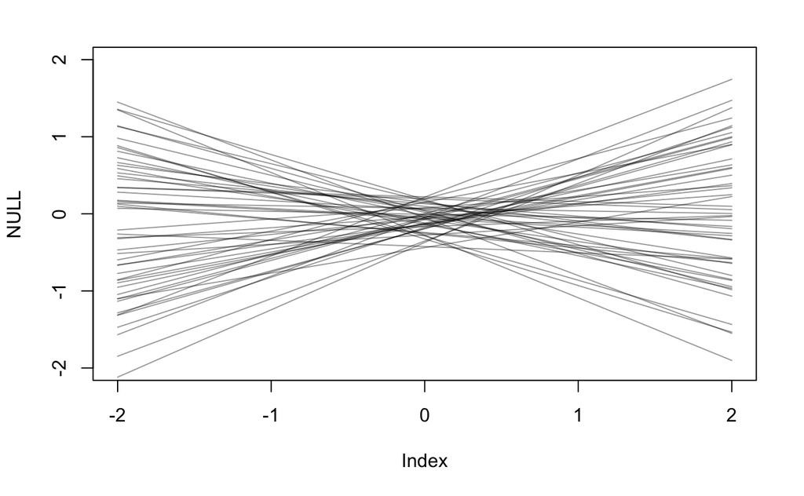

```r
#simulate from priors, single variate A
set.seed(10)
prior <- extract.prior(mh.2A)
mu <- link(mh.2A, post=prior, data=list(A=c(-2, 2)))
plot(NULL, xlim=c(-2, 2), ylim=c(-2, 2))
for (i in 1:50) lines(c(-2, 2), mu[i,], col=col.alpha("black", 0.4))
```

# multiple regression

```r
mh.2 <- quap(
  alist(
    W ~ dnorm(mu, sigma) ,
    mu <- a + bA*A + bH*H,
    a ~ dnorm(0, 0.2),
    bA ~ dnorm(0, 0.5),
    bH ~ dnorm(0, 0.5),
    sigma ~ dexp(1)
  ), data=d3
)
precis(mh.2)
```

|  | mean | sd | 5.5% | 94.5% |
| --- | --- | --- | --- | --- |
| a | 0.00 | 0.02 | -0.03 | 0.03 |
| bA | 0.07 | 0.05 | -0.01 | 0.16 |
| bH | 0.90 | 0.05 | 0.81 | 0.98 |
| sigma | 0.26 | 0.02 | 0.23 | 0.28 |

The direct path of A -> is no longer signficant

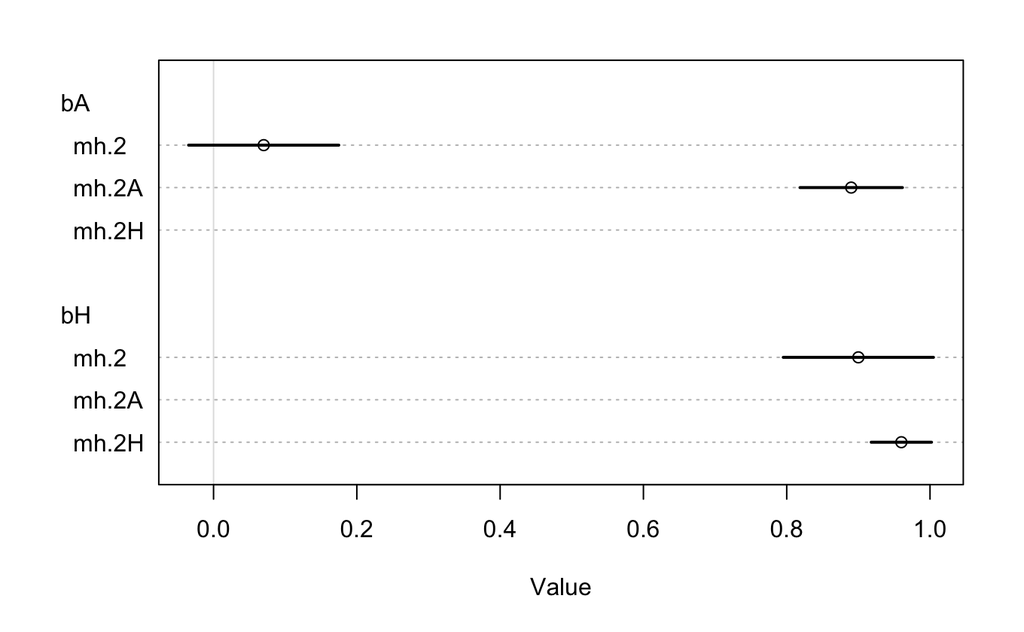

```r
plot(coeftab(mh.2H, mh.2A, mh.2), par=c("bA", "bH"))
```

Once we know the height of individual, there is little or no additional predictive power in also knowing the age.

Counterfactual - simulate effects of varying age

```r
mh.2_A <-quap(
  alist(
  ## A -> W <- H
    W ~ dnorm(mu, sigma) ,
    mu <- a + bA*A + bH*H,
    a ~ dnorm(0, 0.2),
    bA ~ dnorm(0, 0.5),
    bH ~ dnorm(0, 0.5),
    sigma ~ dexp(1),
  ## A -> H
    H ~ dnorm(mu_H, sigma_H) ,
    mu_H <- aH + bAH*A,
    aH ~ dnorm(0, 0.2),
    bAH ~ dnorm(0, 0.5),
    sigma_H ~ dexp(1)
  ), data=d3
)
precis(mh.2_A)
```

|  | mean | sd | 5.5% | 94.5% |
| --- | --- | --- | --- | --- |
| a | 0.00 | 0.02 | -0.03 | 0.03 |
| bA | 0.07 | 0.05 | -0.01 | 0.16 |
| bH | 0.90 | 0.05 | 0.81 | 0.98 |
| sigma | 0.26 | 0.02 | 0.23 | 0.28 |
| aH | 0.00 | 0.03 | -0.05 | 0.05 |
| bAH | 0.91 | 0.03 | 0.86 | 0.97 |
| sigma_H | 0.39 | 0.02 | 0.36 | 0.43 |

bAH tells us that age and height are strongly correlated.

Simulate values of age:

```r
A_seq <- seq(from=-2, to=2, length.out=30)
sim_dat <- data.frame(A=A_seq)
```

```r
# display counterfactual predictions
plot(sim_dat$A, colMeans(s$W), ylim=c(-2, 2), type="l",
        xlab="manipulated A", ylab="counterfactual W")
shade(apply(s$W, 2, PI), sim_dat$A)
```

[output not shown]

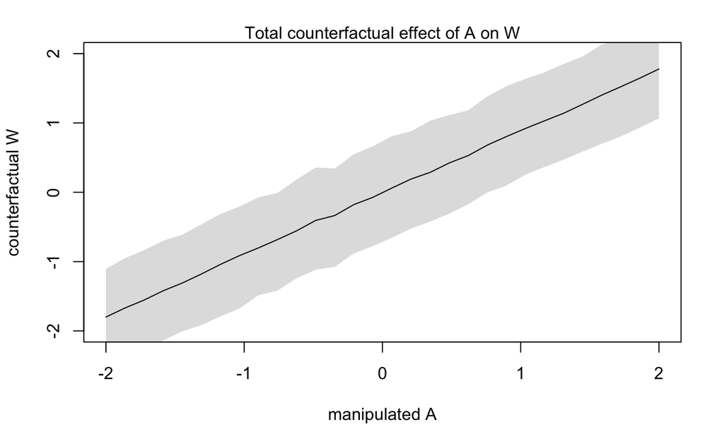

```r
mtext("Total counterfactual effect of A on W")
```

How is this differnt from the one-variable linear regression of A on W?

3. Now suppose the causal association between age and weight might be different for boys and girls. Use a single linear regression, with a categorical variable for sex, to estimate the total causal effect of age on weight separately for boys and girls. How do girls and boys differ? Provide one or more posterior contrasts as a summary.

```r
d3$sex <- ifelse( d3$male ==1, 2, 1)
str(d3$sex)
```

```
 num [1:146] 2 1 1 1 2 2 1 1 1 1 ...
```

```r
mh.3 <-quap(
  alist(
    W ~ dnorm(mu, sigma) ,
    mu <- a[sex] + bA[sex]*A,
    a[sex] ~ dnorm(0, 0.2),
    bA[sex] ~ dnorm(0, 0.5),
    sigma ~ dexp(1)
  ), data=d3
)
precis(mh.3, depth=2)
```

[output not shown]

```r
post <- extract.samples(mh.3)
post$diff_fm <- post$a[,1] - post$a[,2]
precis(post, depth=2)
```

```
quap posterior: 10000 samples from mh.3
```

|  | mean | sd | 5.5% | 94.5% | histogram |
| --- | --- | --- | --- | --- | --- |
| sigma | 0.42 | 0.02 | 0.38 | 0.46 | ▁▁▁▃▇▇▃▁▁▁ |
| a[1] | -0.11 | 0.05 | -0.19 | -0.03 | ▁▁▃▇▇▂▁▁ |
| a[2] | 0.11 | 0.05 | 0.04 | 0.19 | ▁▁▂▅▇▃▁▁ |
| bA[1] | 0.85 | 0.05 | 0.78 | 0.93 | ▁▁▁▂▇▇▃▁▁ |
| bA[2] | 0.92 | 0.05 | 0.84 | 1.00 | ▁▁▂▅▇▃▁▁▁ |
| diff_fm | -0.23 | 0.07 | -0.33 | -0.12 | ▁▁▁▂▅▇▅▂▁▁▁ |

For males, there is a slightly higher causal effect of age on weight.